# Part II - Loan data exploration

## by Mohamed Laayouni

## Investigation Overview

> I will be looking to analyze the distribution of borrowers across states in the US in this dataset as well as the impact some features in this dataset, notably open credit lines and open credit lines in the last 7 years have on a borrowers credit grade.

From a preliminary analysis, this dataset seems to contain 113,937 datapoints pertaining to borrowers information distrubted across 81 features. The main features in this dataset are: CurrentCreditLines, LoanStatus & CreditGrade

## Dataset Overview

> This data set contains information about loans. It has 113,937 rows with 81 columns.

## Visualization 1

This visualization will depict an overview of the states with most loans in this dataset. I have taken the liberty to plot the count of lonas in all states present in this dataset and emphasized my analysis on the 5 highest count ones, these states, in order, are:

1. California: 14717 borrowers
2. Texas: 6842 borrowers
3. New york: 6729 borrowers
4. Florida: 6720 borrowers
5. Illinois: 5921 borrowers

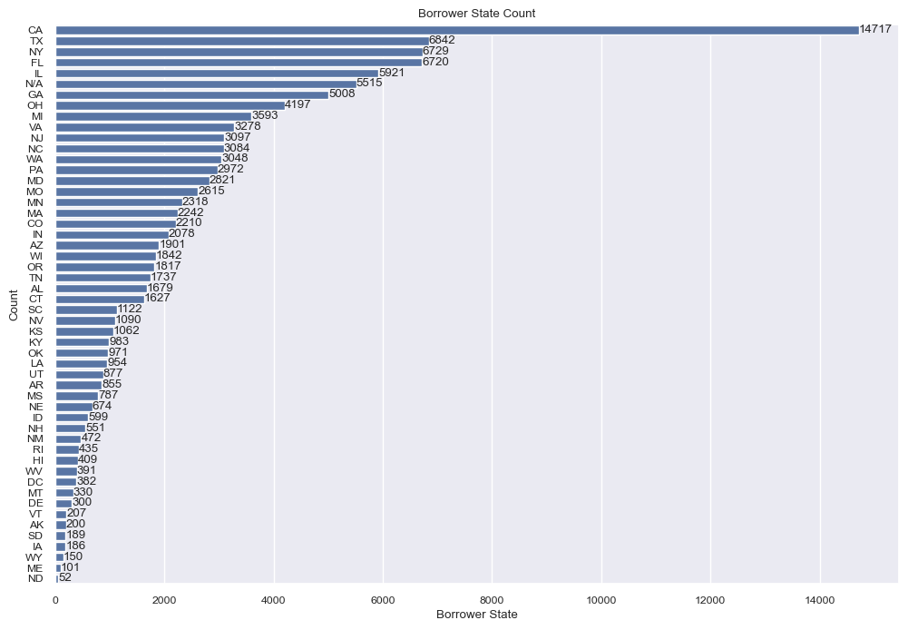

## Visualization 2

The second visualizations goes over the relationship between Income range in this dataset and the loan status. This relationship is depicted by the loan status total for each income range. As we can see below, the borrowers with an income range of 50,000-74,999 dollars are more likely to have their loans still ongoing, while the lower income range borrowers of 25,000-49,999 dollars are more likely to complete their loans than other borrowers.

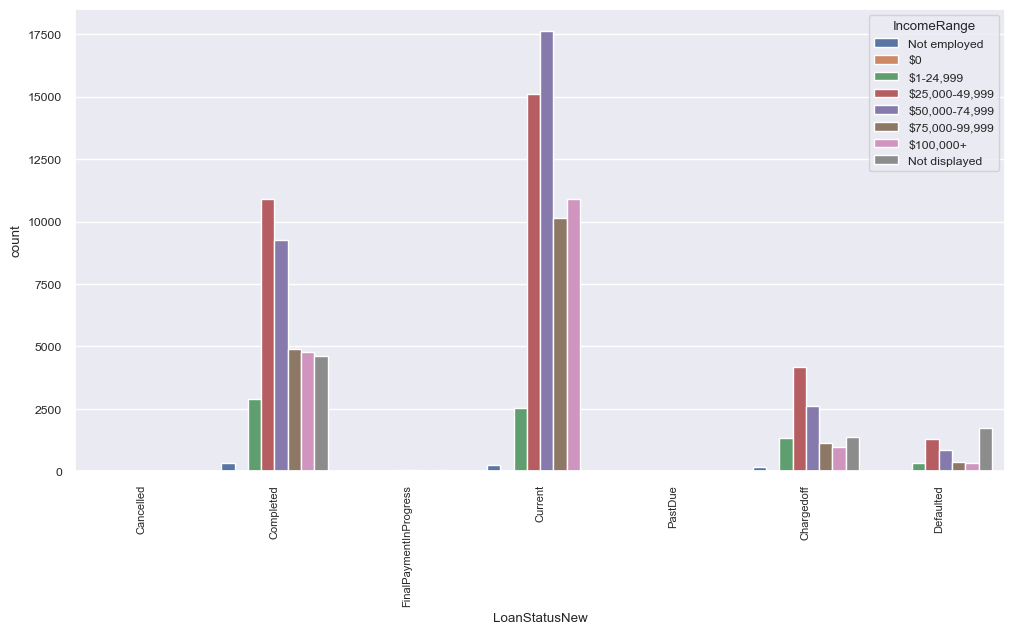

## Visualization 3

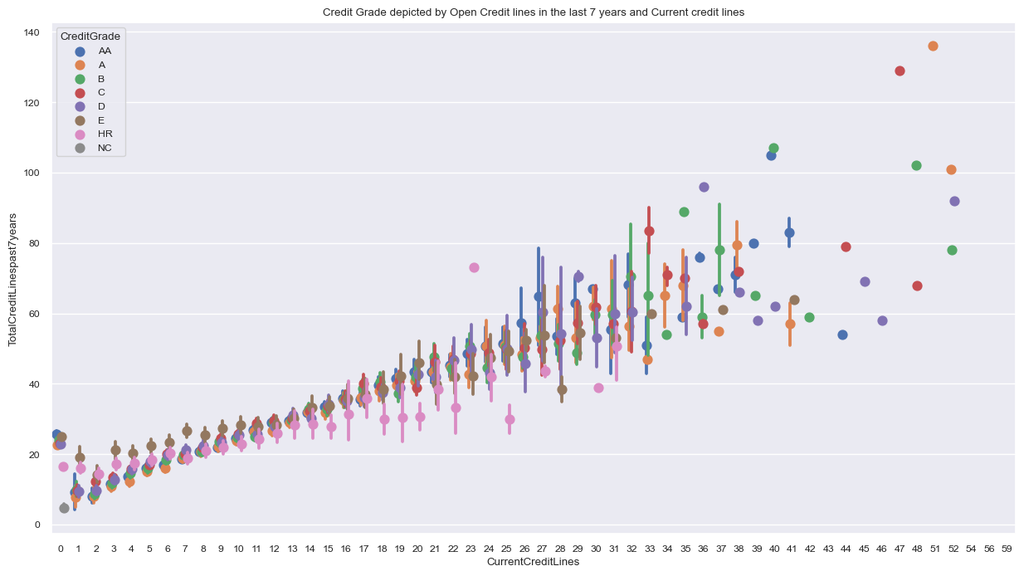